# Kidney Transplant SISA Unlearning

This notebook implements **Sharded, Isolated, Sliced and Aggregated (SISA)** training for the synthetic longitudinal kidney-transplant assessments. The forward-looking target is acute rejection during the 30 days after an assessment—not kidney failure. Complete six-assessment recipient episodes and linked donor data stay in one shard.

SISA must be organised before deletion requests: isolation limits retraining to affected shards, slices provide rollback points, and shard probabilities are averaged. We report a common monolithic full-retraining comparison separately from an exact method-matched clean SISA comparison. Behavioural similarity is not proof of complete internal deletion, and this research system is not clinically validated.

## 2. Imports, Configuration and Paths

This setup reloads immutable baseline and deletion artifacts. Creating all directories first avoids hidden dependence on an interactive session or pre-existing folders.

```python
from __future__ import annotations

import copy
import hashlib
import json
import platform
import random
import time
from pathlib import Path

import joblib
import matplotlib.pyplot as plt
import numpy as np
import pandas as pd
import scipy
import sklearn
import torch
from IPython.display import Markdown, display
from scipy.stats import ks_2samp
from sklearn.metrics import (accuracy_score, average_precision_score, balanced_accuracy_score,
                             brier_score_loss, confusion_matrix, f1_score, log_loss,
                             precision_score, recall_score, roc_auc_score)
from torch import nn
from torch.utils.data import DataLoader, TensorDataset

plt.style.use("seaborn-v0_8-whitegrid")
```

```python
RANDOM_SEED = 42
SHARD_COUNT = 5
SLICE_COUNT = 5
EPOCHS_PER_STAGE = 3
BATCH_SIZE = 128
LEARNING_RATE = 0.001
EPSILON = 1e-7

# The shard and slice layout is fixed before any deletion request exists.
random.seed(RANDOM_SEED); np.random.seed(RANDOM_SEED); torch.manual_seed(RANDOM_SEED)
DEVICE = torch.device("mps" if torch.backends.mps.is_available() else "cuda" if torch.cuda.is_available() else "cpu")
print(f"SISA configuration: {SHARD_COUNT} shards × {SLICE_COUNT} slices | device: {DEVICE}")
```

```
SISA configuration: 5 shards × 5 slices | device: mps
```

```python
def locate_code_root(start: Path) -> Path:
    for candidate in [start, *start.parents]:
        direct = candidate / "data/processed/KidneyTransplant/kidney_transplant_assessments_clean.csv"
        nested = candidate / "code/data/processed/KidneyTransplant/kidney_transplant_assessments_clean.csv"
        if direct.is_file(): return candidate
        if nested.is_file(): return candidate / "code"
    raise FileNotFoundError("Could not locate processed KidneyTransplant data.")

def sha256(path: Path) -> str: return hashlib.sha256(path.read_bytes()).hexdigest()
def index_hash(values): return hashlib.sha256(np.asarray(values, dtype=np.int64).tobytes()).hexdigest()

CODE_ROOT = locate_code_root(Path.cwd().resolve())
DATA_PATH = CODE_ROOT / "data/processed/KidneyTransplant/kidney_transplant_assessments_clean.csv"
BASELINE_RESULTS = CODE_ROOT / "results/KidneyTransplant/baseline"
BASELINE_MODEL_PATH = CODE_ROOT / "models/KidneyTransplant/baseline/kidney_transplant_baseline_mlp.pt"
BASELINE_PREPROCESSOR_PATH = CODE_ROOT / "models/KidneyTransplant/baseline/kidney_transplant_preprocessor.joblib"
FULL_RESULTS = CODE_ROOT / "results/KidneyTransplant/full_retraining"
FULL_MODELS = CODE_ROOT / "models/KidneyTransplant/full_retraining"
RESULTS_ROOT = CODE_ROOT / "results/KidneyTransplant/sisa"
MODEL_ROOT = CODE_ROOT / "models/KidneyTransplant/sisa"
```

```python
OUTPUT_DIRS = {name: RESULTS_ROOT / name for name in
               ["configuration", "histories", "metrics", "tables", "figures", "checkpoints"]}
# Create every destination before training to avoid reliance on stale folders.
for directory in [MODEL_ROOT, *OUTPUT_DIRS.values()]: directory.mkdir(parents=True, exist_ok=True)
display(pd.DataFrame([
    {"artifact": "baseline inputs", "path": BASELINE_MODEL_PATH.parent.relative_to(CODE_ROOT)},
    {"artifact": "SISA models", "path": MODEL_ROOT.relative_to(CODE_ROOT)},
    {"artifact": "SISA results", "path": RESULTS_ROOT.relative_to(CODE_ROOT)},
]).style.hide(axis="index"))
```

| artifact | path |
| --- | --- |
| baseline inputs | models/KidneyTransplant/baseline |
| SISA models | models/KidneyTransplant/sisa |
| SISA results | results/KidneyTransplant/sisa |

## 3. Reload and Verify Upstream State

Saved row indices and hashes preserve the same training population and deletion requests used by every method.

```python
baseline_manifest = json.loads((BASELINE_RESULTS / "configuration/baseline_manifest.json").read_text())
full_manifest = json.loads((FULL_RESULTS / "configuration/full_retraining_manifest.json").read_text())
baseline_checkpoint = torch.load(BASELINE_MODEL_PATH, map_location="cpu", weights_only=False)
baseline_preprocessor = joblib.load(BASELINE_PREPROCESSOR_PATH)
clean_df = pd.read_csv(DATA_PATH)

FEATURE_COLUMNS = baseline_checkpoint["feature_columns"]
EXCLUDED_COLUMNS = baseline_checkpoint["excluded_audit_columns"]
TARGET_COLUMN = baseline_checkpoint["target_column"]
THRESHOLD = float(baseline_checkpoint["fixed_baseline_validation_threshold"])
ARCHITECTURE = baseline_checkpoint["architecture"]
SCENARIOS = full_manifest["deletion_configuration"]
SCENARIO_NAMES = list(SCENARIOS)

assert sha256(DATA_PATH) == baseline_manifest["processed_dataset_hash"] == full_manifest["dataset_hash"]
assert THRESHOLD == full_manifest["threshold"]
```

```python
split_indices = {name: np.load(CODE_ROOT / item["index_path"], allow_pickle=False)
                 for name, item in baseline_manifest["split_artifacts"].items()}
# Saved baseline positions preserve the original recipient-grouped experiment.
train_indices, validation_indices, test_indices = (split_indices[name] for name in ["train", "validation", "test"])
forget_indices = {name: np.load(FULL_RESULTS / f"indices/{name}_forget_indices.npy", allow_pickle=False)
                  for name in SCENARIO_NAMES}
retain_indices = {name: np.load(FULL_RESULTS / f"indices/{name}_retain_indices.npy", allow_pickle=False)
                  for name in SCENARIO_NAMES}
for name in SCENARIO_NAMES:
    assert set(forget_indices[name]).isdisjoint(retain_indices[name])
    assert set(forget_indices[name]) | set(retain_indices[name]) == set(train_indices)
    assert index_hash(forget_indices[name]) == full_manifest["index_hashes"][name]["forget"]
```

```python
features = clean_df[FEATURE_COLUMNS]
target = clean_df[TARGET_COLUMN].astype(int)
metadata = clean_df[["recipient_id", "donor_id", "hospital_id", "training_consent_version",
                     "assessment_date", "days_since_transplant"]].copy()
metadata["assessment_date"] = pd.to_datetime(metadata["assessment_date"], errors="raise")
metadata["derived_transplant_date"] = metadata["assessment_date"] - pd.to_timedelta(metadata["days_since_transplant"], unit="D")

def related_mask(frame, name):
    # Entity IDs cannot cross splits, but provider and cohort rules can match holdouts.
    if name == "s3_hospital_withdrawal": return frame["hospital_id"].eq("H07")
    if name == "s4_invalid_consent": return frame["training_consent_version"].eq("RECIPIENT_V3")
    if name == "s5_retention_expiry":
        cutoff = metadata.loc[forget_indices[name], "derived_transplant_date"].max()
        return frame["derived_transplant_date"].le(cutoff)
    return pd.Series(False, index=frame.index)
```

## 4. Recipient-Grouped Shards and Ordered Slices

Assignment happens at recipient level so no longitudinal or donor-linked episode crosses shards. Slices are fixed before any deletion request.

```python
training_recipients = np.sort(metadata.loc[train_indices, "recipient_id"].unique())
shuffled_recipients = np.random.default_rng(RANDOM_SEED).permutation(training_recipients)
recipient_shards = np.array_split(shuffled_recipients, SHARD_COUNT)

SHARD_SLICES = {}
assignment_rows = []
for shard_id, shard_recipients in enumerate(recipient_shards):
    # The shuffled order is frozen; consecutive blocks define deterministic replay stages.
    recipient_slices = np.array_split(shard_recipients, SLICE_COUNT)
    SHARD_SLICES[shard_id] = []
    for slice_id, recipients in enumerate(recipient_slices, start=1):
        rows = metadata.loc[train_indices].index[metadata.loc[train_indices, "recipient_id"].isin(recipients)].to_numpy(np.int64)
        SHARD_SLICES[shard_id].append(rows)
        assignment_rows.append({"shard": shard_id, "slice": slice_id,
                                "recipients": len(recipients), "rows": len(rows)})
assignment = pd.DataFrame(assignment_rows)
display(assignment.style.hide(axis="index"))
```

| shard | slice | recipients | rows |
| --- | --- | --- | --- |
| 0 | 1 | 280 | 1680 |
| 0 | 2 | 280 | 1680 |
| 0 | 3 | 280 | 1680 |
| 0 | 4 | 280 | 1680 |
| 0 | 5 | 280 | 1680 |
| 1 | 1 | 280 | 1680 |
| 1 | 2 | 280 | 1680 |
| 1 | 3 | 280 | 1680 |
| 1 | 4 | 280 | 1680 |
| 1 | 5 | 280 | 1680 |
| 2 | 1 | 280 | 1680 |
| 2 | 2 | 280 | 1680 |
| 2 | 3 | 280 | 1680 |
| 2 | 4 | 280 | 1680 |
| 2 | 5 | 280 | 1680 |
| 3 | 1 | 280 | 1680 |
| 3 | 2 | 280 | 1680 |
| 3 | 3 | 280 | 1680 |
| 3 | 4 | 280 | 1680 |
| 3 | 5 | 280 | 1680 |
| 4 | 1 | 280 | 1680 |
| 4 | 2 | 280 | 1680 |
| 4 | 3 | 280 | 1680 |
| 4 | 4 | 280 | 1680 |
| 4 | 5 | 280 | 1680 |

```python
# Verify every recipient and donor appears in exactly one shard.
row_to_shard = {}
for shard_id, slices in SHARD_SLICES.items():
    for row in np.concatenate(slices): row_to_shard[int(row)] = shard_id
assert set(row_to_shard) == set(train_indices)
recipient_shard_counts = metadata.loc[train_indices].assign(
    shard=[row_to_shard[int(i)] for i in train_indices]
).groupby("recipient_id")["shard"].nunique()
donor_shard_counts = metadata.loc[train_indices].assign(
    shard=[row_to_shard[int(i)] for i in train_indices]
).groupby("donor_id")["shard"].nunique()
assert recipient_shard_counts.eq(1).all() and donor_shard_counts.eq(1).all()
assert assignment.groupby("shard")["rows"].sum().eq(8_400).all()
print("All 7,000 recipient episodes and linked donors are isolated within one shard.")
```

```
All 7,000 recipient episodes and linked donors are isolated within one shard.
```

## 5. SISA Model and Deterministic Stage Training

A checkpoint after slice k contains cumulative training through slices 1…k. Checkpoint 0 is the deterministic initial state before any rows are seen.

```python
class KidneyMLP(nn.Module):
    def __init__(self, input_dim):
        super().__init__(); h1, h2 = ARCHITECTURE["hidden_layer_dimensions"]
        self.network = nn.Sequential(nn.Linear(input_dim, h1), nn.ReLU(),
                                     nn.Dropout(ARCHITECTURE["dropout_probability"]),
                                     nn.Linear(h1, h2), nn.ReLU(), nn.Linear(h2, 1))
    def forward(self, values): return self.network(values).squeeze(1)

def fresh_model(shard_id):
    # Isolated shard seeds make both clean training and replay deterministic.
    seed = RANDOM_SEED + shard_id
    random.seed(seed); np.random.seed(seed); torch.manual_seed(seed)
    return KidneyMLP(baseline_checkpoint["input_dim"]).to(DEVICE)

def clone_state(model):
    return {key: value.detach().cpu().clone() for key, value in model.state_dict().items()}
```

```python
def train_stage(model, row_indices, shard_id, slice_id):
    # A stage retrains on all retained rows available through the current slice.
    processed = baseline_preprocessor.transform(features.loc[row_indices]).astype(np.float32)
    dataset = TensorDataset(torch.tensor(processed), torch.tensor(target.loc[row_indices].to_numpy(), dtype=torch.float32))
    loader = DataLoader(dataset, batch_size=BATCH_SIZE, shuffle=True,
                        generator=torch.Generator().manual_seed(RANDOM_SEED + 100*shard_id + slice_id))
    optimizer = torch.optim.Adam(model.parameters(), lr=LEARNING_RATE,
                                 weight_decay=baseline_checkpoint["training_configuration"]["weight_decay"])
    criterion = nn.BCEWithLogitsLoss(); loss_sum = 0.0; rows = 0
    model.train()
    for _ in range(EPOCHS_PER_STAGE):
        for batch_x, batch_y in loader:
            optimizer.zero_grad(); loss = criterion(model(batch_x.to(DEVICE)), batch_y.to(DEVICE))
            loss.backward(); optimizer.step(); loss_sum += loss.item()*len(batch_y); rows += len(batch_y)
    return loss_sum / rows

def train_ensemble(excluded_rows=None):
    # Clean references use this identical procedure with forget rows removed from every stage.
    excluded = set() if excluded_rows is None else set(np.asarray(excluded_rows).tolist())
    models, checkpoints, histories = {}, {}, []
    started = time.perf_counter()
    for shard_id in range(SHARD_COUNT):
        model = fresh_model(shard_id); checkpoints[shard_id] = {0: clone_state(model)}
        cumulative = []
        for slice_id, slice_rows in enumerate(SHARD_SLICES[shard_id], start=1):
            cumulative.extend(int(row) for row in slice_rows if int(row) not in excluded)
            loss = train_stage(model, np.asarray(cumulative, dtype=np.int64), shard_id, slice_id)
            checkpoints[shard_id][slice_id] = clone_state(model)
            histories.append({"shard": shard_id, "slice": slice_id, "cumulative_rows": len(cumulative), "training_bce": loss})
        models[shard_id] = model
    return models, checkpoints, pd.DataFrame(histories), time.perf_counter()-started
```

## 6. Initial SISA Training

Initial cost is paid before deletion requests. These checkpoints are the rollback states used by replay.

```python
initial_models, initial_checkpoints, initial_history, initial_runtime = train_ensemble()
# Initial training is an up-front lifecycle cost, not a deletion-request cost.
display(initial_history.style.hide(axis="index").format(precision=5))
print(f"Initial SISA training runtime: {initial_runtime:.2f} seconds")
```

| shard | slice | cumulative_rows | training_bce |
| --- | --- | --- | --- |
| 0 | 1 | 1680 | 0.49808 |
| 0 | 2 | 3360 | 0.17364 |
| 0 | 3 | 5040 | 0.10469 |
| 0 | 4 | 6720 | 0.08923 |
| 0 | 5 | 8400 | 0.08697 |
| 1 | 1 | 1680 | 0.53077 |
| 1 | 2 | 3360 | 0.17359 |
| 1 | 3 | 5040 | 0.09782 |
| 1 | 4 | 6720 | 0.10217 |
| 1 | 5 | 8400 | 0.10116 |
| 2 | 1 | 1680 | 0.63539 |
| 2 | 2 | 3360 | 0.25012 |
| 2 | 3 | 5040 | 0.09444 |
| 2 | 4 | 6720 | 0.09517 |
| 2 | 5 | 8400 | 0.09371 |
| 3 | 1 | 1680 | 0.67434 |
| 3 | 2 | 3360 | 0.25935 |
| 3 | 3 | 5040 | 0.12159 |
| 3 | 4 | 6720 | 0.11207 |
| 3 | 5 | 8400 | 0.10213 |
| 4 | 1 | 1680 | 0.72086 |
| 4 | 2 | 3360 | 0.45062 |
| 4 | 3 | 5040 | 0.12225 |
| 4 | 4 | 6720 | 0.09763 |
| 4 | 5 | 8400 | 0.09638 |

```
Initial SISA training runtime: 12.57 seconds
```

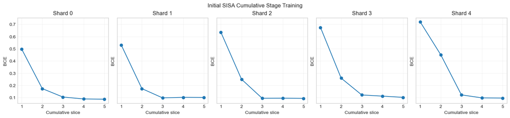

```python
history_figure, history_axes = plt.subplots(1, 5, figsize=(15, 3.4), sharey=True, constrained_layout=True)
for shard_id, axis in enumerate(history_axes):
    rows = initial_history.query("shard == @shard_id")
    axis.plot(rows["slice"], rows["training_bce"], marker="o")
    axis.set(title=f"Shard {shard_id}", xlabel="Cumulative slice", ylabel="BCE")
    axis.grid(alpha=0.25)
history_figure.suptitle("Initial SISA Cumulative Stage Training")
display(history_figure); plt.close(history_figure)
```

## 7. Rollback and Selective Replay

For each affected shard, replay begins from the checkpoint immediately before its earliest affected slice. Unaffected shards reuse their original final model.

```python
def affected_plan(forget_rows):
    # The earliest touched slice determines the rollback boundary for each shard.
    forgotten = set(np.asarray(forget_rows).tolist()); plan = {}
    for shard_id, slices in SHARD_SLICES.items():
        affected = [slice_id for slice_id, rows in enumerate(slices, start=1) if forgotten & set(rows.tolist())]
        if affected: plan[shard_id] = min(affected)
    return plan

def replay_scenario(name):
    forgotten = set(forget_indices[name].tolist()); plan = affected_plan(forget_indices[name])
    # Unaffected shards retain their original final state without replay.
    models = {shard: copy.deepcopy(model) for shard, model in initial_models.items()}
    history = []; started = time.perf_counter(); replay_row_visits = 0
    for shard_id, earliest in plan.items():
        model = fresh_model(shard_id); model.load_state_dict(initial_checkpoints[shard_id][earliest-1])
        cumulative = [int(row) for rows in SHARD_SLICES[shard_id][:earliest-1] for row in rows if int(row) not in forgotten]
        for slice_id in range(earliest, SLICE_COUNT+1):
            cumulative.extend(int(row) for row in SHARD_SLICES[shard_id][slice_id-1] if int(row) not in forgotten)
            loss = train_stage(model, np.asarray(cumulative, np.int64), shard_id, slice_id)
            replay_row_visits += len(cumulative)
            history.append({"scenario": name, "shard": shard_id, "slice": slice_id,
                            "cumulative_rows": len(cumulative), "training_bce": loss})
        models[shard_id] = model
    return models, pd.DataFrame(history), time.perf_counter()-started, plan, replay_row_visits
```

```python
replay_runs = {}
for name in SCENARIO_NAMES:
    models, history, runtime, plan, row_visits = replay_scenario(name)
    replay_runs[name] = {"models": models, "history": history, "runtime_seconds": runtime,
                         "plan": plan, "replay_row_visits": row_visits}
    print(f"{name}: affected shards {plan}; replay {runtime:.2f} seconds")
```

```
s1_recipient_withdrawal: affected shards {0: 1, 1: 1, 2: 1, 3: 1, 4: 1}; replay 12.03 seconds
```

```
s2_living_donor_withdrawal: affected shards {0: 1, 1: 1, 2: 1, 3: 1, 4: 1}; replay 11.45 seconds
```

```
s3_hospital_withdrawal: affected shards {0: 1, 1: 1, 2: 1, 3: 1, 4: 1}; replay 10.34 seconds
```

```
s4_invalid_consent: affected shards {0: 1, 1: 1, 2: 1, 3: 1, 4: 1}; replay 10.10 seconds
```

```
s5_retention_expiry: affected shards {0: 1, 1: 1, 2: 1, 3: 1, 4: 1}; replay 9.64 seconds
```

## 8. Clean Retain-Only SISA References

A method-matched reference trains the same SISA procedure from its deterministic initial states after removing the request. Exact equality tests replay correctness, not similarity to a monolithic model.

```python
clean_runs = {}
for name in SCENARIO_NAMES:
    models, checkpoints, history, runtime = train_ensemble(excluded_rows=forget_indices[name])
    clean_runs[name] = {"models": models, "checkpoints": checkpoints, "history": history,
                        "runtime_seconds": runtime}
    print(f"{name}: clean retain-only SISA {runtime:.2f} seconds")
```

```
s1_recipient_withdrawal: clean retain-only SISA 10.89 seconds
```

```
s2_living_donor_withdrawal: clean retain-only SISA 10.27 seconds
```

```
s3_hospital_withdrawal: clean retain-only SISA 9.72 seconds
```

```
s4_invalid_consent: clean retain-only SISA 9.70 seconds
```

```
s5_retention_expiry: clean retain-only SISA 9.20 seconds
```

## 9. Shared Prediction and Metric Definitions

All shard outputs are probabilities and receive equal weight. The same fixed threshold and classifier Truth Ratio definitions are used in Notebooks 03–05.

```python
def predict_model(model, preprocessor, raw_features):
    processed = preprocessor.transform(raw_features).astype(np.float32); model.eval()
    with torch.no_grad(): logits = model(torch.tensor(processed, device=DEVICE))
    return torch.sigmoid(logits).cpu().numpy()

def ensemble_predict(models, raw_features):
    # Equal probability averaging is the predefined SISA aggregation rule.
    shard_probabilities = [predict_model(models[shard], baseline_preprocessor, raw_features)
                           for shard in range(SHARD_COUNT)]
    return np.mean(shard_probabilities, axis=0)

def utility_metrics(labels, probabilities):
    p = np.clip(np.asarray(probabilities, float), EPSILON, 1-EPSILON); predictions = p >= THRESHOLD
    matrix = confusion_matrix(labels, predictions, labels=[0,1]); tn, fp, fn, tp = matrix.ravel()
    return {"auroc": roc_auc_score(labels,p), "pr_auc": average_precision_score(labels,p),
            "brier_score": brier_score_loss(labels,p), "bce": log_loss(labels,p,labels=[0,1]),
            "f1": f1_score(labels,predictions,zero_division=0),
            "balanced_accuracy": balanced_accuracy_score(labels,predictions),
            "precision": precision_score(labels,predictions,zero_division=0),
            "recall": recall_score(labels,predictions,zero_division=0), "specificity": tn/(tn+fp),
            "tn":tn,"fp":fp,"fn":fn,"tp":tp}
```

```python
def truth_ratio(labels, probabilities):
    # This binary classifier adaptation is inspired by, but is not, generative TOFU.
    y = labels.to_numpy(float); p = np.clip(np.asarray(probabilities,float), EPSILON,1-EPSILON)
    p_correct = np.clip(y*p + (1-y)*(1-p), EPSILON,1-EPSILON)
    return (1-p_correct)/p_correct

def forget_quality(labels, original, unlearned, reference):
    before = ks_2samp(truth_ratio(labels,original), truth_ratio(labels,reference))
    after = ks_2samp(truth_ratio(labels,unlearned), truth_ratio(labels,reference))
    before_mae=np.abs(original-reference).mean(); after_mae=np.abs(unlearned-reference).mean(); y=labels.to_numpy(float)
    confidence=lambda p:(y*p+(1-y)*(1-p)).mean()
    return {"ks_d_before":before.statistic,"ks_d_after":after.statistic,
            "ks_d_improvement":before.statistic-after.statistic,"ks_p_value_after":after.pvalue,
            "probability_mae_before":before_mae,"probability_mae_after":after_mae,
            "probability_mae_improvement":before_mae-after_mae,
            "prediction_agreement_after":((unlearned>=THRESHOLD)==(reference>=THRESHOLD)).mean(),
            "absolute_bce_difference_after":abs(log_loss(labels,np.clip(unlearned,EPSILON,1-EPSILON),labels=[0,1])-
                                                log_loss(labels,np.clip(reference,EPSILON,1-EPSILON),labels=[0,1])),
            "absolute_confidence_difference_after":abs(confidence(unlearned)-confidence(reference)),
            "forget_rows":len(labels)}
```

## 10. Common Monolithic Reference Results

This comparison uses Notebook 02 full retraining for cross-method context. It is deliberately kept separate from replay verification because SISA and monolithic training have different optimisation structures.

```python
baseline_model = KidneyMLP(baseline_checkpoint["input_dim"]); baseline_model.load_state_dict(baseline_checkpoint["state_dict"]); baseline_model=baseline_model.to(DEVICE)
common_rows, utility_rows = [], []
for name in SCENARIO_NAMES:
    # Common monolithic references enable cross-method behavioural comparison.
    validation_match = related_mask(metadata.loc[validation_indices], name)
    test_match = related_mask(metadata.loc[test_indices], name)
    retained_test_x = features.loc[test_match.index[~test_match]]; retained_test_y = target.loc[test_match.index[~test_match]]
    full_checkpoint = torch.load(FULL_MODELS/name/"model.pt",map_location="cpu",weights_only=False)
    full_model=KidneyMLP(full_checkpoint["input_dim"]); full_model.load_state_dict(full_checkpoint["state_dict"]); full_model=full_model.to(DEVICE)
    full_preprocessor=joblib.load(FULL_MODELS/name/"preprocessor.joblib")
    probabilities={"original":predict_model(baseline_model,baseline_preprocessor,retained_test_x),
                   "sisa_replay":ensemble_predict(replay_runs[name]["models"],retained_test_x),
                   "full_retraining":predict_model(full_model,full_preprocessor,retained_test_x)}
    for model_name,p in probabilities.items(): utility_rows.append({"scenario":name,"model":model_name,
        "retained_test_rows":len(retained_test_y),"threshold":THRESHOLD,**utility_metrics(retained_test_y,p)})
    forget_x=features.loc[forget_indices[name]]; forget_y=target.loc[forget_indices[name]]
    common_rows.append({"scenario":name,"reference":"common_monolithic_full_retraining",**forget_quality(
        forget_y,predict_model(baseline_model,baseline_preprocessor,forget_x),
        ensemble_predict(replay_runs[name]["models"],forget_x),predict_model(full_model,full_preprocessor,forget_x))})
common_utility=pd.DataFrame(utility_rows); common_forget_quality=pd.DataFrame(common_rows)
display(common_utility.style.hide(axis="index").format(precision=4))
display(common_forget_quality.style.hide(axis="index").format(precision=5))
```

| scenario | model | retained_test_rows | threshold | auroc | pr_auc | brier_score | bce | f1 | balanced_accuracy | precision | recall | specificity | tn | fp | fn | tp |
| --- | --- | --- | --- | --- | --- | --- | --- | --- | --- | --- | --- | --- | --- | --- | --- | --- |
| s1_recipient_withdrawal | original | 9000 | 0.2600 | 0.8785 | 0.2819 | 0.0230 | 0.0931 | 0.2892 | 0.6132 | 0.3688 | 0.2379 | 0.9885 | 8651 | 101 | 189 | 59 |
| s1_recipient_withdrawal | sisa_replay | 9000 | 0.2600 | 0.8700 | 0.2470 | 0.0238 | 0.0960 | 0.2045 | 0.5626 | 0.4923 | 0.1290 | 0.9962 | 8719 | 33 | 216 | 32 |
| s1_recipient_withdrawal | full_retraining | 9000 | 0.2600 | 0.8767 | 0.2835 | 0.0230 | 0.0932 | 0.2843 | 0.6078 | 0.3836 | 0.2258 | 0.9897 | 8662 | 90 | 192 | 56 |
| s2_living_donor_withdrawal | original | 9000 | 0.2600 | 0.8785 | 0.2819 | 0.0230 | 0.0931 | 0.2892 | 0.6132 | 0.3688 | 0.2379 | 0.9885 | 8651 | 101 | 189 | 59 |
| s2_living_donor_withdrawal | sisa_replay | 9000 | 0.2600 | 0.8694 | 0.2493 | 0.0238 | 0.0962 | 0.2038 | 0.5626 | 0.4848 | 0.1290 | 0.9961 | 8718 | 34 | 216 | 32 |
| s2_living_donor_withdrawal | full_retraining | 9000 | 0.2600 | 0.8765 | 0.2831 | 0.0230 | 0.0932 | 0.2940 | 0.6169 | 0.3653 | 0.2460 | 0.9879 | 8646 | 106 | 187 | 61 |
| s3_hospital_withdrawal | original | 8100 | 0.2600 | 0.8855 | 0.2688 | 0.0223 | 0.0894 | 0.2809 | 0.6110 | 0.3521 | 0.2336 | 0.9883 | 7794 | 92 | 164 | 50 |
| s3_hospital_withdrawal | sisa_replay | 8100 | 0.2600 | 0.8731 | 0.2364 | 0.0229 | 0.0929 | 0.1776 | 0.5523 | 0.5111 | 0.1075 | 0.9972 | 7864 | 22 | 191 | 23 |
| s3_hospital_withdrawal | full_retraining | 8100 | 0.2600 | 0.8794 | 0.2587 | 0.0224 | 0.0907 | 0.2717 | 0.6044 | 0.3561 | 0.2196 | 0.9892 | 7801 | 85 | 167 | 47 |
| s4_invalid_consent | original | 8100 | 0.2600 | 0.8739 | 0.2819 | 0.0224 | 0.0918 | 0.2905 | 0.6137 | 0.3714 | 0.2385 | 0.9888 | 7794 | 88 | 166 | 52 |
| s4_invalid_consent | sisa_replay | 8100 | 0.2600 | 0.8652 | 0.2431 | 0.0233 | 0.0951 | 0.2022 | 0.5605 | 0.5510 | 0.1239 | 0.9972 | 7860 | 22 | 191 | 27 |
| s4_invalid_consent | full_retraining | 8100 | 0.2600 | 0.8736 | 0.2926 | 0.0223 | 0.0914 | 0.2890 | 0.6116 | 0.3778 | 0.2339 | 0.9893 | 7798 | 84 | 167 | 51 |
| s5_retention_expiry | original | 7692 | 0.2600 | 0.8753 | 0.2696 | 0.0233 | 0.0943 | 0.2783 | 0.6075 | 0.3609 | 0.2264 | 0.9886 | 7395 | 85 | 164 | 48 |
| s5_retention_expiry | sisa_replay | 7692 | 0.2600 | 0.8659 | 0.2328 | 0.0240 | 0.0972 | 0.2090 | 0.5642 | 0.5000 | 0.1321 | 0.9963 | 7452 | 28 | 184 | 28 |
| s5_retention_expiry | full_retraining | 7692 | 0.2600 | 0.8705 | 0.2732 | 0.0232 | 0.0950 | 0.2515 | 0.5918 | 0.3596 | 0.1934 | 0.9902 | 7407 | 73 | 171 | 41 |

| scenario | reference | ks_d_before | ks_d_after | ks_d_improvement | ks_p_value_after | probability_mae_before | probability_mae_after | probability_mae_improvement | prediction_agreement_after | absolute_bce_difference_after | absolute_confidence_difference_after | forget_rows |
| --- | --- | --- | --- | --- | --- | --- | --- | --- | --- | --- | --- | --- |
| s1_recipient_withdrawal | common_monolithic_full_retraining | 0.04048 | 0.09524 | -0.05476 | 0.04426 | 0.00416 | 0.00993 | -0.00577 | 0.99048 | 0.00358 | 0.00277 | 420 |
| s2_living_donor_withdrawal | common_monolithic_full_retraining | 0.05619 | 0.01952 | 0.03667 | 0.81847 | 0.00358 | 0.00777 | -0.00419 | 0.99143 | 0.00033 | 0.00210 | 2100 |
| s3_hospital_withdrawal | common_monolithic_full_retraining | 0.04214 | 0.08452 | -0.04238 | 0.00000 | 0.00554 | 0.01189 | -0.00636 | 0.98976 | 0.00422 | 0.00373 | 4200 |
| s4_invalid_consent | common_monolithic_full_retraining | 0.03000 | 0.04452 | -0.01452 | 0.00048 | 0.00559 | 0.01274 | -0.00715 | 0.98571 | 0.00197 | 0.00183 | 4200 |
| s5_retention_expiry | common_monolithic_full_retraining | 0.01857 | 0.08413 | -0.06556 | 0.00000 | 0.00580 | 0.01096 | -0.00515 | 0.99222 | 0.00391 | 0.00504 | 6300 |

The common-reference KS D and probability MAE support comparison with other methods. P-values remain supporting only, and no arbitrary pass threshold is applied.

## 11. Method-Matched Replay Verification

Replay and clean retain-only SISA should be deterministic equivalents. Maximum probability difference is paired with parameter equality checks.

```python
method_rows=[]
for name in SCENARIO_NAMES:
    # Clean SISA isolates replay correctness from monolithic optimisation differences.
    forget_x=features.loc[forget_indices[name]]; forget_y=target.loc[forget_indices[name]]
    initial=ensemble_predict(initial_models,forget_x); replay=ensemble_predict(replay_runs[name]["models"],forget_x)
    clean=ensemble_predict(clean_runs[name]["models"],forget_x)
    parameter_match=all(all(torch.equal(replay_runs[name]["models"][shard].state_dict()[key].cpu(),
                                        clean_runs[name]["models"][shard].state_dict()[key].cpu())
                                  for key in replay_runs[name]["models"][shard].state_dict())
                        for shard in range(SHARD_COUNT))
    metrics=forget_quality(forget_y,initial,replay,clean)
    method_rows.append({"scenario":name,"reference":"clean_retain_only_sisa",
                        "maximum_prediction_difference":np.abs(replay-clean).max(),
                        "parameters_match":parameter_match,**metrics})
method_matched=pd.DataFrame(method_rows)
assert method_matched["parameters_match"].all()
assert np.allclose(method_matched["maximum_prediction_difference"],0,atol=1e-7)
display(method_matched.style.hide(axis="index").format(precision=8))
```

| scenario | reference | maximum_prediction_difference | parameters_match | ks_d_before | ks_d_after | ks_d_improvement | ks_p_value_after | probability_mae_before | probability_mae_after | probability_mae_improvement | prediction_agreement_after | absolute_bce_difference_after | absolute_confidence_difference_after | forget_rows |
| --- | --- | --- | --- | --- | --- | --- | --- | --- | --- | --- | --- | --- | --- | --- |
| s1_recipient_withdrawal | clean_retain_only_sisa | 0.00000000 | True | 0.01666667 | 0.00000000 | 0.01666667 | 1.00000000 | 0.00096569 | 0.00000000 | 0.00096569 | 1.00000000 | 0.00000000 | 0.00000000 | 420 |
| s2_living_donor_withdrawal | clean_retain_only_sisa | 0.00000000 | True | 0.02809524 | 0.00000000 | 0.02809524 | 1.00000000 | 0.00079253 | 0.00000000 | 0.00079253 | 1.00000000 | 0.00000000 | 0.00000000 | 2100 |
| s3_hospital_withdrawal | clean_retain_only_sisa | 0.00000000 | True | 0.01285714 | 0.00000000 | 0.01285714 | 1.00000000 | 0.00157337 | 0.00000000 | 0.00157337 | 1.00000000 | 0.00000000 | 0.00000000 | 4200 |
| s4_invalid_consent | clean_retain_only_sisa | 0.00000000 | True | 0.02857143 | 0.00000000 | 0.02857143 | 1.00000000 | 0.00169393 | 0.00000000 | 0.00169393 | 1.00000000 | 0.00000000 | 0.00000000 | 4200 |
| s5_retention_expiry | clean_retain_only_sisa | 0.00000000 | True | 0.03793651 | 0.00000000 | 0.03793651 | 1.00000000 | 0.00233195 | 0.00000000 | 0.00233195 | 1.00000000 | 0.00000000 | 0.00000000 | 6300 |

Exact method-matched equality verifies deterministic replay under this frozen preprocessing and training procedure. It does not establish certified deletion from every possible internal representation.

## 12. Replay Cost and Lifecycle Efficiency

Request-only speed-up excludes initial training; lifecycle cost includes it. Reporting both avoids hiding SISA's up-front cost.

```python
initial_row_visits = int(sum(row["cumulative_rows"] for row in initial_history.to_dict("records")))
# Row visits provide a hardware-independent complement to wall-clock timing.
full_runtime=pd.read_csv(FULL_RESULTS/"tables/training_summary.csv").set_index("scenario")
runtime_rows=[]
for name in SCENARIO_NAMES:
    run=replay_runs[name]; full_seconds=float(full_runtime.loc[name,"runtime_seconds"])
    runtime_rows.append({"scenario":name,"affected_shards":len(run["plan"]),
        "earliest_affected_slice":min(run["plan"].values()),"replay_row_visits":run["replay_row_visits"],
        "initial_row_visits":initial_row_visits,"replay_fraction":run["replay_row_visits"]/initial_row_visits,
        "initial_training_seconds":initial_runtime,"replay_seconds":run["runtime_seconds"],
        "total_lifecycle_seconds":initial_runtime+run["runtime_seconds"],
        "full_retraining_seconds":full_seconds,"request_only_speed_up":full_seconds/run["runtime_seconds"],
        "total_lifecycle_speed_up":full_seconds/(initial_runtime+run["runtime_seconds"])})
runtime_metrics=pd.DataFrame(runtime_rows)
display(runtime_metrics.style.hide(axis="index").format({"replay_fraction":"{:.2%}",
    "initial_training_seconds":"{:.2f}","replay_seconds":"{:.2f}","total_lifecycle_seconds":"{:.2f}",
    "full_retraining_seconds":"{:.2f}","request_only_speed_up":"{:.2f}×","total_lifecycle_speed_up":"{:.2f}×"}))
```

| scenario | affected_shards | earliest_affected_slice | replay_row_visits | initial_row_visits | replay_fraction | initial_training_seconds | replay_seconds | total_lifecycle_seconds | full_retraining_seconds | request_only_speed_up | total_lifecycle_speed_up |
| --- | --- | --- | --- | --- | --- | --- | --- | --- | --- | --- | --- |
| s1_recipient_withdrawal | 5 | 1 | 124860 | 126000 | 99.10% | 12.57 | 12.03 | 24.59 | 27.25 | 2.27× | 1.11× |
| s2_living_donor_withdrawal | 5 | 1 | 119850 | 126000 | 95.12% | 12.57 | 11.45 | 24.01 | 25.28 | 2.21× | 1.05× |
| s3_hospital_withdrawal | 5 | 1 | 113442 | 126000 | 90.03% | 12.57 | 10.34 | 22.91 | 25.39 | 2.45× | 1.11× |
| s4_invalid_consent | 5 | 1 | 113460 | 126000 | 90.05% | 12.57 | 10.10 | 22.67 | 25.68 | 2.54× | 1.13× |
| s5_retention_expiry | 5 | 1 | 107148 | 126000 | 85.04% | 12.57 | 9.64 | 22.21 | 20.82 | 2.16× | 0.94× |

```python
checkpoint_bytes=sum(tensor.numel()*tensor.element_size()
                     for shard in initial_checkpoints.values() for state in shard.values() for tensor in state.values())
storage_summary=pd.DataFrame([{"saved_checkpoints":SHARD_COUNT*(SLICE_COUNT+1),
                               "checkpoint_storage_bytes":checkpoint_bytes,
                               "checkpoint_storage_megabytes":checkpoint_bytes/1024**2}])
display(storage_summary.style.hide(axis="index").format({"checkpoint_storage_megabytes":"{:.3f}"}))
```

| saved_checkpoints | checkpoint_storage_bytes | checkpoint_storage_megabytes |
| --- | --- | --- |
| 30 | 169080 | 0.161 |

## 13. Figures

Shared scenario ordering shows common-reference forgetting, paired probability distance, and replay efficiency without merging method-matched and monolithic claims.

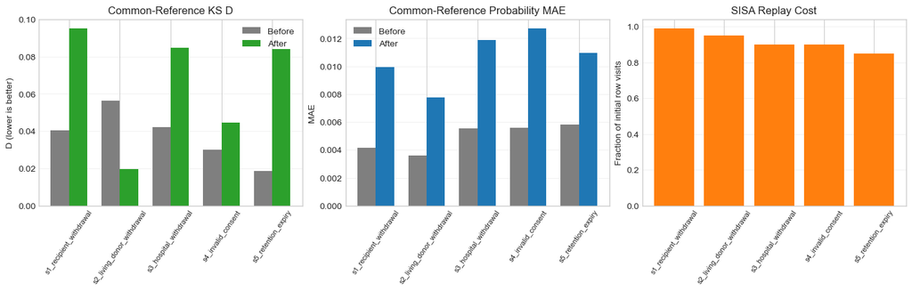

```python
comparison_figure,axes=plt.subplots(1,3,figsize=(14,4.4),constrained_layout=True); x=np.arange(len(SCENARIO_NAMES)); width=.36
axes[0].bar(x-width/2,common_forget_quality["ks_d_before"],width,label="Before",color="#7f7f7f")
axes[0].bar(x+width/2,common_forget_quality["ks_d_after"],width,label="After",color="#2ca02c")
axes[0].set(title="Common-Reference KS D",ylabel="D (lower is better)",xticks=x,xticklabels=SCENARIO_NAMES); axes[0].legend()
axes[1].bar(x-width/2,common_forget_quality["probability_mae_before"],width,label="Before",color="#7f7f7f")
axes[1].bar(x+width/2,common_forget_quality["probability_mae_after"],width,label="After",color="#1f77b4")
axes[1].set(title="Common-Reference Probability MAE",ylabel="MAE",xticks=x,xticklabels=SCENARIO_NAMES); axes[1].legend()
axes[2].bar(runtime_metrics["scenario"],runtime_metrics["replay_fraction"],color="#ff7f0e")
axes[2].set(title="SISA Replay Cost",ylabel="Fraction of initial row visits")
for axis in axes: axis.tick_params(axis="x",rotation=55,labelsize=8); axis.grid(axis="y",alpha=.25)
display(comparison_figure); plt.close(comparison_figure)
```

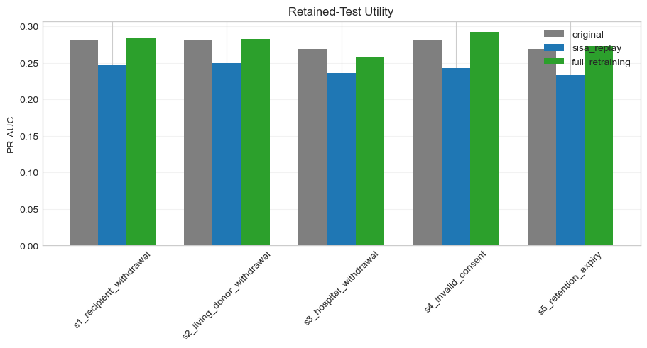

```python
utility_figure,axis=plt.subplots(figsize=(9,4.8),constrained_layout=True)
models=["original","sisa_replay","full_retraining"]; colours=["#7f7f7f","#1f77b4","#2ca02c"]
x=np.arange(len(SCENARIO_NAMES)); width=.25
for offset,(model,colour) in enumerate(zip(models,colours)):
    rows=common_utility.query("model == @model")
    axis.bar(x+(offset-1)*width,rows["pr_auc"],width,label=model,color=colour)
axis.set(title="Retained-Test Utility",ylabel="PR-AUC",xticks=x,xticklabels=SCENARIO_NAMES)
axis.tick_params(axis="x",rotation=45); axis.legend(); axis.grid(axis="y",alpha=.25)
display(utility_figure); plt.close(utility_figure)
```

## 14. Centralised Saving

Initial checkpoints, replay ensembles, clean references, tables and figures are saved after computation, then hashed for auditability.

```python
TABLES={"assignment":(assignment,OUTPUT_DIRS["tables"]/"shard_slice_assignment.csv"),
        "initial_history":(initial_history,OUTPUT_DIRS["histories"]/"initial_training_history.csv"),
        "utility":(common_utility,OUTPUT_DIRS["metrics"]/"common_reference_utility.csv"),
        "common_forget":(common_forget_quality,OUTPUT_DIRS["metrics"]/"common_reference_forget_quality.csv"),
        "matched":(method_matched,OUTPUT_DIRS["metrics"]/"method_matched_verification.csv"),
        "runtime":(runtime_metrics,OUTPUT_DIRS["tables"]/"runtime_metrics.csv"),
        "storage":(storage_summary,OUTPUT_DIRS["tables"]/"checkpoint_storage.csv")}
for frame,path in TABLES.values(): frame.to_csv(path,index=False)
for name,run in replay_runs.items(): run["history"].to_csv(OUTPUT_DIRS["histories"]/f"{name}_replay_history.csv",index=False)
```

```python
# Persist every initial stage checkpoint with explicit after-slice semantics.
for shard_id,stages in initial_checkpoints.items():
    shard_dir=OUTPUT_DIRS["checkpoints"]/f"shard_{shard_id}"; shard_dir.mkdir(parents=True,exist_ok=True)
    for stage,state in stages.items(): torch.save({"state_dict":state,"shard":shard_id,"completed_slices":stage},shard_dir/f"after_slice_{stage}.pt")

MODEL_PATHS={}; CLEAN_MODEL_PATHS={}
for name in SCENARIO_NAMES:
    scenario_dir=MODEL_ROOT/name; scenario_dir.mkdir(parents=True,exist_ok=True)
    MODEL_PATHS[name]=[]; CLEAN_MODEL_PATHS[name]=[]
    for shard_id in range(SHARD_COUNT):
        path=scenario_dir/f"replayed_shard_{shard_id}.pt"; MODEL_PATHS[name].append(path)
        torch.save({"state_dict":clone_state(replay_runs[name]["models"][shard_id]),"input_dim":baseline_checkpoint["input_dim"],
                    "scenario":name,"shard":shard_id,"method":"sisa_replay","threshold":THRESHOLD,
                    "forget_index_hash":index_hash(forget_indices[name])},path)
        clean_path=scenario_dir/f"clean_reference_shard_{shard_id}.pt"; CLEAN_MODEL_PATHS[name].append(clean_path)
        torch.save({"state_dict":clone_state(clean_runs[name]["models"][shard_id]),"input_dim":baseline_checkpoint["input_dim"],
                    "scenario":name,"shard":shard_id,"method":"clean_retain_only_sisa_reference",
                    "threshold":THRESHOLD,"forget_index_hash":index_hash(forget_indices[name])},clean_path)
```

```python
FIGURES={"histories":OUTPUT_DIRS["figures"]/"initial_sisa_histories.png",
         "comparison":OUTPUT_DIRS["figures"]/"forgetting_and_replay_cost.png",
         "utility":OUTPUT_DIRS["figures"]/"retained_utility.png"}
history_figure.savefig(FIGURES["histories"],dpi=300,bbox_inches="tight")
comparison_figure.savefig(FIGURES["comparison"],dpi=300,bbox_inches="tight")
utility_figure.savefig(FIGURES["utility"],dpi=300,bbox_inches="tight")

manifest={"method":"SISA","configuration":{"shards":SHARD_COUNT,"slices":SLICE_COUNT,"epochs_per_stage":EPOCHS_PER_STAGE,
            "seed":RANDOM_SEED,"checkpoint_semantics":"after_slice_k contains cumulative training through slices 1..k; slice_0 is initialization"},
          "dataset_path":str(DATA_PATH.relative_to(CODE_ROOT)),"dataset_hash":sha256(DATA_PATH),
          "dataset_description":"Entirely synthetic longitudinal kidney-transplant follow-up assessments.",
          "target":TARGET_COLUMN,"feature_list":FEATURE_COLUMNS,"excluded_audit_fields":EXCLUDED_COLUMNS,
          "split_strategy":baseline_manifest["split_strategy"],"group_key":"recipient_id","seeds":[RANDOM_SEED],
          "threshold":THRESHOLD,"threshold_label":"fixed_baseline_validation_threshold","loss_choice":"BCEWithLogitsLoss",
          "deletion_configuration":SCENARIOS,"index_hashes":full_manifest["index_hashes"],
          "preprocessing_policy":"frozen original training-only preprocessor shared by isolated shards",
          "runtime_environment":{"python":platform.python_version(),"numpy":np.__version__,"pandas":pd.__version__,
            "scipy":scipy.__version__,"scikit_learn":sklearn.__version__,"pytorch":torch.__version__,"device":str(DEVICE)},
          "artifact_hashes":{}}
MANIFEST_PATH=OUTPUT_DIRS["configuration"]/"sisa_manifest.json"
```

```python
artifact_paths=[*[path for _,path in TABLES.values()],*FIGURES.values(),
                *[path for paths in MODEL_PATHS.values() for path in paths],
                *[path for paths in CLEAN_MODEL_PATHS.values() for path in paths]]
artifact_paths+=list(OUTPUT_DIRS["histories"].glob("*.csv"))+list(OUTPUT_DIRS["checkpoints"].glob("**/*.pt"))
# Hash all model, checkpoint, table and figure outputs for the final reload audit.
manifest["artifact_hashes"]={str(path.relative_to(CODE_ROOT)):sha256(path) for path in artifact_paths}
MANIFEST_PATH.write_text(json.dumps(manifest,indent=2))
print(f"Saved {len(artifact_paths)} SISA artifacts and manifest.")
```

```
Saved 96 SISA artifacts and manifest.
```

## 15. Reload and Verification

Reloading verifies checkpoint semantics, predictions, parameter persistence, numeric tables, and artifact hashes.

```python
for frame,path in TABLES.values():
    saved=pd.read_csv(path); assert saved.columns.tolist()==frame.columns.tolist() and len(saved)==len(frame)
    for column in frame.select_dtypes(include=np.number): assert np.allclose(saved[column],frame[column],equal_nan=True)
for name,paths in MODEL_PATHS.items():
    for shard_id,path in enumerate(paths):
        checkpoint=torch.load(path,map_location="cpu",weights_only=False); model=KidneyMLP(checkpoint["input_dim"])
        model.load_state_dict(checkpoint["state_dict"]); model=model.to(DEVICE)
        sample=features.loc[test_indices].iloc[:16]
        assert np.allclose(predict_model(model,baseline_preprocessor,sample),
                           predict_model(replay_runs[name]["models"][shard_id],baseline_preprocessor,sample),rtol=1e-6,atol=1e-7)
assert json.loads(MANIFEST_PATH.read_text())==manifest
assert all(sha256(CODE_ROOT/path)==digest for path,digest in manifest["artifact_hashes"].items())
print("SISA checkpoints, ensembles, predictions, tables, figures and manifest reloaded successfully.")
```

```
SISA checkpoints, ensembles, predictions, tables, figures and manifest reloaded successfully.
```

## 16. Final Discussion

```python
all_shards = runtime_metrics["affected_shards"].eq(SHARD_COUNT).sum()
slice_one = runtime_metrics["earliest_affected_slice"].eq(1).sum()
display(Markdown(
    f"- **Organisation:** 7,000 complete recipient episodes were assigned to {SHARD_COUNT} isolated shards and {SLICE_COUNT} ordered slices.\n"
    "- **Common reference:** monolithic full retraining supports cross-method behavioural comparison.\n"
    "- **Method-matched verification:** replay predictions and parameters equal clean retain-only SISA within deterministic tolerance.\n"
    f"- **Efficiency limitation:** {all_shards} requests affected all shards and {slice_one} reached slice 1; these cases require broad replay.\n"
    "- **Costs:** request-only and lifecycle speed-ups are both reported, alongside checkpoint storage.\n"
    "- **Limitations:** synthetic data, fixed architecture and shard design, behavioural evidence only, and no formal or clinical guarantee."
))
```

- **Organisation:** 7,000 complete recipient episodes were assigned to 5 isolated shards and 5 ordered slices.

- **Common reference:** monolithic full retraining supports cross-method behavioural comparison.

- **Method-matched verification:** replay predictions and parameters equal clean retain-only SISA within deterministic tolerance.

- **Efficiency limitation:** 5 requests affected all shards and 5 reached slice 1; these cases require broad replay.

- **Costs:** request-only and lifecycle speed-ups are both reported, alongside checkpoint storage.

- **Limitations:** synthetic data, fixed architecture and shard design, behavioural evidence only, and no formal or clinical guarantee.